# Risk Factor Analysis

## Outcome Variable

**Outcome Variable:** swasted

## Predictor Variables

**Intervention Variable:** mbmi

**Adjustment Set:**

unadjusted

## Stratifying Variables

The analysis was stratified on these variable(s):

- agecat
- studyid
- country

## Data Summary

| agecat | studyid | country | mbmi | swasted | n_cell | n | outcome_variable |
| --- | --- | --- | --- | --- | --- | --- | --- |
| Birth | ki0047075b-MAL-ED | BANGLADESH | Normal weight | 0 | 175 | 209 | swasted |
| Birth | ki0047075b-MAL-ED | BANGLADESH | Normal weight | 1 | 8 | 209 | swasted |
| Birth | ki0047075b-MAL-ED | BANGLADESH | Underweight | 0 | 26 | 209 | swasted |
| Birth | ki0047075b-MAL-ED | BANGLADESH | Underweight | 1 | 0 | 209 | swasted |
| Birth | ki0047075b-MAL-ED | BRAZIL | Normal weight | 0 | 56 | 61 | swasted |
| Birth | ki0047075b-MAL-ED | BRAZIL | Normal weight | 1 | 0 | 61 | swasted |
| Birth | ki0047075b-MAL-ED | BRAZIL | Underweight | 0 | 5 | 61 | swasted |
| Birth | ki0047075b-MAL-ED | BRAZIL | Underweight | 1 | 0 | 61 | swasted |
| Birth | ki0047075b-MAL-ED | INDIA | Normal weight | 0 | 33 | 41 | swasted |
| Birth | ki0047075b-MAL-ED | INDIA | Normal weight | 1 | 0 | 41 | swasted |
| Birth | ki0047075b-MAL-ED | INDIA | Underweight | 0 | 8 | 41 | swasted |
| Birth | ki0047075b-MAL-ED | INDIA | Underweight | 1 | 0 | 41 | swasted |
| Birth | ki0047075b-MAL-ED | NEPAL | Normal weight | 0 | 25 | 26 | swasted |
| Birth | ki0047075b-MAL-ED | NEPAL | Normal weight | 1 | 1 | 26 | swasted |
| Birth | ki0047075b-MAL-ED | NEPAL | Underweight | 0 | 0 | 26 | swasted |
| Birth | ki0047075b-MAL-ED | NEPAL | Underweight | 1 | 0 | 26 | swasted |
| Birth | ki0047075b-MAL-ED | PERU | Normal weight | 0 | 216 | 221 | swasted |
| Birth | ki0047075b-MAL-ED | PERU | Normal weight | 1 | 0 | 221 | swasted |
| Birth | ki0047075b-MAL-ED | PERU | Underweight | 0 | 5 | 221 | swasted |
| Birth | ki0047075b-MAL-ED | PERU | Underweight | 1 | 0 | 221 | swasted |
| Birth | ki0047075b-MAL-ED | SOUTH AFRICA | Normal weight | 0 | 97 | 100 | swasted |
| Birth | ki0047075b-MAL-ED | SOUTH AFRICA | Normal weight | 1 | 0 | 100 | swasted |
| Birth | ki0047075b-MAL-ED | SOUTH AFRICA | Underweight | 0 | 3 | 100 | swasted |
| Birth | ki0047075b-MAL-ED | SOUTH AFRICA | Underweight | 1 | 0 | 100 | swasted |
| Birth | ki0047075b-MAL-ED | TANZANIA, UNITED REPUBLIC OF | Normal weight | 0 | 107 | 113 | swasted |
| Birth | ki0047075b-MAL-ED | TANZANIA, UNITED REPUBLIC OF | Normal weight | 1 | 0 | 113 | swasted |
| Birth | ki0047075b-MAL-ED | TANZANIA, UNITED REPUBLIC OF | Underweight | 0 | 6 | 113 | swasted |
| Birth | ki0047075b-MAL-ED | TANZANIA, UNITED REPUBLIC OF | Underweight | 1 | 0 | 113 | swasted |
| Birth | ki1000304b-SAS-CompFeed | INDIA | Normal weight | 0 | 722 | 992 | swasted |
| Birth | ki1000304b-SAS-CompFeed | INDIA | Normal weight | 1 | 13 | 992 | swasted |

[output cut: 150 more lines]

The following strata were considered:

- agecat: 24 months, studyid: ki0047075b-MAL-ED, country: BANGLADESH
- agecat: 24 months, studyid: ki0047075b-MAL-ED, country: BRAZIL
- agecat: 24 months, studyid: ki0047075b-MAL-ED, country: INDIA
- agecat: 24 months, studyid: ki0047075b-MAL-ED, country: NEPAL
- agecat: 24 months, studyid: ki0047075b-MAL-ED, country: PERU
- agecat: 24 months, studyid: ki0047075b-MAL-ED, country: SOUTH AFRICA
- agecat: 24 months, studyid: ki0047075b-MAL-ED, country: TANZANIA, UNITED REPUBLIC OF
- agecat: 24 months, studyid: ki1017093-NIH-Birth, country: BANGLADESH
- agecat: 24 months, studyid: ki1017093b-PROVIDE, country: BANGLADESH
- agecat: 24 months, studyid: ki1017093c-NIH-Crypto, country: BANGLADESH
- agecat: 24 months, studyid: ki1066203-TanzaniaChild2, country: TANZANIA, UNITED REPUBLIC OF
- agecat: 24 months, studyid: ki1119695-PROBIT, country: BELARUS
- agecat: 24 months, studyid: ki1126311-ZVITAMBO, country: ZIMBABWE
- agecat: 24 months, studyid: ki1148112-LCNI-5, country: MALAWI
- agecat: 24 months, studyid: kiGH5241-JiVitA-3, country: BANGLADESH
- agecat: 6 months, studyid: ki0047075b-MAL-ED, country: BANGLADESH
- agecat: 6 months, studyid: ki0047075b-MAL-ED, country: BRAZIL
- agecat: 6 months, studyid: ki0047075b-MAL-ED, country: INDIA
- agecat: 6 months, studyid: ki0047075b-MAL-ED, country: NEPAL
- agecat: 6 months, studyid: ki0047075b-MAL-ED, country: PERU
- agecat: 6 months, studyid: ki0047075b-MAL-ED, country: SOUTH AFRICA
- agecat: 6 months, studyid: ki0047075b-MAL-ED, country: TANZANIA, UNITED REPUBLIC OF
- agecat: 6 months, studyid: ki1000304b-SAS-CompFeed, country: INDIA
- agecat: 6 months, studyid: ki1017093-NIH-Birth, country: BANGLADESH
- agecat: 6 months, studyid: ki1017093b-PROVIDE, country: BANGLADESH
- agecat: 6 months, studyid: ki1017093c-NIH-Crypto, country: BANGLADESH
- agecat: 6 months, studyid: ki1066203-TanzaniaChild2, country: TANZANIA, UNITED REPUBLIC OF
- agecat: 6 months, studyid: ki1119695-PROBIT, country: BELARUS
- agecat: 6 months, studyid: ki1126311-ZVITAMBO, country: ZIMBABWE
- agecat: 6 months, studyid: ki1148112-LCNI-5, country: MALAWI
- agecat: 6 months, studyid: kiGH5241-JiVitA-3, country: BANGLADESH
- agecat: Birth, studyid: ki0047075b-MAL-ED, country: BANGLADESH
- agecat: Birth, studyid: ki0047075b-MAL-ED, country: BRAZIL
- agecat: Birth, studyid: ki0047075b-MAL-ED, country: INDIA
- agecat: Birth, studyid: ki0047075b-MAL-ED, country: NEPAL
- agecat: Birth, studyid: ki0047075b-MAL-ED, country: PERU
- agecat: Birth, studyid: ki0047075b-MAL-ED, country: SOUTH AFRICA
- agecat: Birth, studyid: ki0047075b-MAL-ED, country: TANZANIA, UNITED REPUBLIC OF
- agecat: Birth, studyid: ki1000304b-SAS-CompFeed, country: INDIA
- agecat: Birth, studyid: ki1017093-NIH-Birth, country: BANGLADESH
- agecat: Birth, studyid: ki1017093b-PROVIDE, country: BANGLADESH
- agecat: Birth, studyid: ki1017093c-NIH-Crypto, country: BANGLADESH
- agecat: Birth, studyid: ki1119695-PROBIT, country: BELARUS
- agecat: Birth, studyid: ki1126311-ZVITAMBO, country: ZIMBABWE
- agecat: Birth, studyid: kiGH5241-JiVitA-3, country: BANGLADESH

### Dropped Strata

Some strata were dropped due to rare outcomes:

- agecat: Birth, studyid: ki0047075b-MAL-ED, country: BANGLADESH
- agecat: Birth, studyid: ki0047075b-MAL-ED, country: BRAZIL
- agecat: Birth, studyid: ki0047075b-MAL-ED, country: INDIA
- agecat: Birth, studyid: ki0047075b-MAL-ED, country: NEPAL
- agecat: Birth, studyid: ki0047075b-MAL-ED, country: PERU
- agecat: Birth, studyid: ki0047075b-MAL-ED, country: SOUTH AFRICA
- agecat: Birth, studyid: ki0047075b-MAL-ED, country: TANZANIA, UNITED REPUBLIC OF
- agecat: Birth, studyid: ki1017093b-PROVIDE, country: BANGLADESH
- agecat: 6 months, studyid: ki0047075b-MAL-ED, country: BANGLADESH
- agecat: 6 months, studyid: ki0047075b-MAL-ED, country: BRAZIL
- agecat: 6 months, studyid: ki0047075b-MAL-ED, country: INDIA
- agecat: 6 months, studyid: ki0047075b-MAL-ED, country: NEPAL
- agecat: 6 months, studyid: ki0047075b-MAL-ED, country: PERU
- agecat: 6 months, studyid: ki0047075b-MAL-ED, country: SOUTH AFRICA
- agecat: 6 months, studyid: ki0047075b-MAL-ED, country: TANZANIA, UNITED REPUBLIC OF
- agecat: 6 months, studyid: ki1017093-NIH-Birth, country: BANGLADESH
- agecat: 6 months, studyid: ki1017093b-PROVIDE, country: BANGLADESH
- agecat: 6 months, studyid: ki1017093c-NIH-Crypto, country: BANGLADESH
- agecat: 6 months, studyid: ki1066203-TanzaniaChild2, country: TANZANIA, UNITED REPUBLIC OF
- agecat: 6 months, studyid: ki1119695-PROBIT, country: BELARUS
- agecat: 6 months, studyid: ki1148112-LCNI-5, country: MALAWI
- agecat: 24 months, studyid: ki0047075b-MAL-ED, country: BANGLADESH
- agecat: 24 months, studyid: ki0047075b-MAL-ED, country: BRAZIL
- agecat: 24 months, studyid: ki0047075b-MAL-ED, country: INDIA
- agecat: 24 months, studyid: ki0047075b-MAL-ED, country: NEPAL
- agecat: 24 months, studyid: ki0047075b-MAL-ED, country: PERU
- agecat: 24 months, studyid: ki0047075b-MAL-ED, country: SOUTH AFRICA
- agecat: 24 months, studyid: ki0047075b-MAL-ED, country: TANZANIA, UNITED REPUBLIC OF
- agecat: 24 months, studyid: ki1017093-NIH-Birth, country: BANGLADESH
- agecat: 24 months, studyid: ki1017093b-PROVIDE, country: BANGLADESH
- agecat: 24 months, studyid: ki1017093c-NIH-Crypto, country: BANGLADESH
- agecat: 24 months, studyid: ki1066203-TanzaniaChild2, country: TANZANIA, UNITED REPUBLIC OF
- agecat: 24 months, studyid: ki1119695-PROBIT, country: BELARUS
- agecat: 24 months, studyid: ki1126311-ZVITAMBO, country: ZIMBABWE
- agecat: 24 months, studyid: ki1148112-LCNI-5, country: MALAWI

## Methods Detail

We’re interested in the causal parameters $E[Y_a]$ for all values of $a \in \mathcal{A}$. These parameters represent the mean outcome if, possibly contrary to fact, we intervened to set all units to have $A=a$. Under the randomization and positivity assumptions, these are identified by the statistical parameters $\psi_a=E_W[E_{Y|A,W}(Y|A=a,W)]$. In addition, we’re interested in the mean of $Y$, $E[Y]$ under no intervention (the observed mean). We will estimate these parameters by using SuperLearner to fit the relevant likelihood factors – $E_{Y|A,W}(Y|A=a,W)$ and $p(A=a|W)$, and then updating our likelihood fit using a joint TMLE.

For unadjusted analyses ($W=\{\}$), initial likelihoods were estimated using Lrnr_glm to estimate the simple $E(Y|A)$ and Lrnr_mean to estimate $p(A)$. For adjusted analyses, a small library containing Lrnr_glmnet, Lrnr_xgboost, and Lrnr_mean was used.

Having estimated these parameters, we will then use the delta method to estimate relative risks and attributable risks relative to a prespecified baseline level of $A$.

# Results Detail

## Results Plots

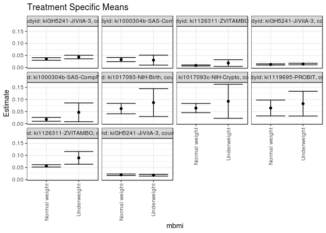

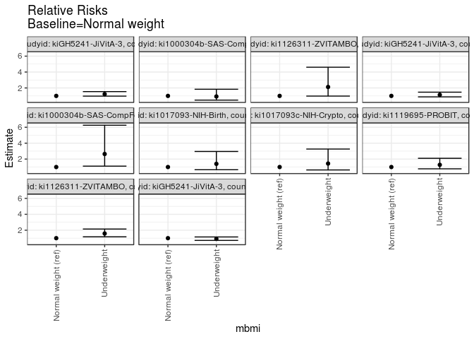

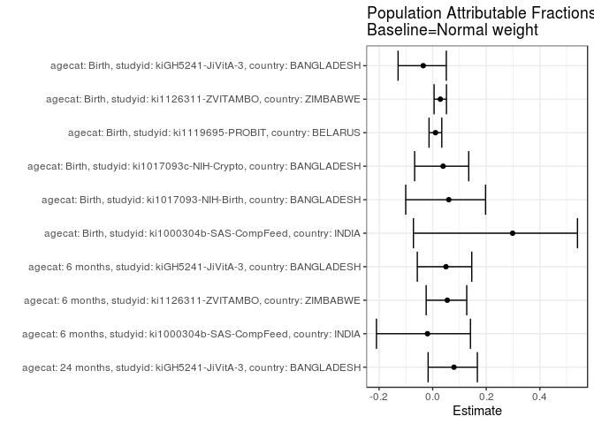

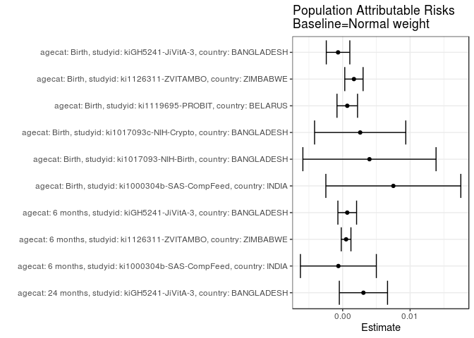

## Results Table

### Parameter: TSM

| agecat | studyid | country | intervention_level | baseline_level | estimate | ci_lower | ci_upper |
| --- | --- | --- | --- | --- | --- | --- | --- |
| Birth | ki1000304b-SAS-CompFeed | INDIA | Normal weight | NA | 0.0176871 | 0.0097268 | 0.0256474 |
| Birth | ki1000304b-SAS-CompFeed | INDIA | Underweight | NA | 0.0466926 | 0.0080265 | 0.0853587 |
| Birth | ki1017093-NIH-Birth | BANGLADESH | Normal weight | NA | 0.0621118 | 0.0405684 | 0.0836552 |
| Birth | ki1017093-NIH-Birth | BANGLADESH | Underweight | NA | 0.0869565 | 0.0293291 | 0.1445839 |
| Birth | ki1017093c-NIH-Crypto | BANGLADESH | Normal weight | NA | 0.0641628 | 0.0451499 | 0.0831756 |
| Birth | ki1017093c-NIH-Crypto | BANGLADESH | Underweight | NA | 0.0923077 | 0.0218889 | 0.1627264 |
| Birth | ki1119695-PROBIT | BELARUS | Normal weight | NA | 0.0645971 | 0.0318484 | 0.0973459 |
| Birth | ki1119695-PROBIT | BELARUS | Underweight | NA | 0.0825336 | 0.0313432 | 0.1337239 |
| Birth | ki1126311-ZVITAMBO | ZIMBABWE | Normal weight | NA | 0.0567996 | 0.0519001 | 0.0616992 |
| Birth | ki1126311-ZVITAMBO | ZIMBABWE | Underweight | NA | 0.0899123 | 0.0636555 | 0.1161690 |
| Birth | kiGH5241-JiVitA-3 | BANGLADESH | Normal weight | NA | 0.0200293 | 0.0169075 | 0.0231510 |
| Birth | kiGH5241-JiVitA-3 | BANGLADESH | Underweight | NA | 0.0182831 | 0.0147911 | 0.0217751 |
| 6 months | ki1000304b-SAS-CompFeed | INDIA | Normal weight | NA | 0.0332594 | 0.0247526 | 0.0417662 |
| 6 months | ki1000304b-SAS-CompFeed | INDIA | Underweight | NA | 0.0308642 | 0.0102057 | 0.0515227 |
| 6 months | ki1126311-ZVITAMBO | ZIMBABWE | Normal weight | NA | 0.0088650 | 0.0066501 | 0.0110799 |
| 6 months | ki1126311-ZVITAMBO | ZIMBABWE | Underweight | NA | 0.0188172 | 0.0050083 | 0.0326261 |
| 6 months | kiGH5241-JiVitA-3 | BANGLADESH | Normal weight | NA | 0.0130059 | 0.0105192 | 0.0154927 |
| 6 months | kiGH5241-JiVitA-3 | BANGLADESH | Underweight | NA | 0.0147745 | 0.0117132 | 0.0178357 |
| 24 months | kiGH5241-JiVitA-3 | BANGLADESH | Normal weight | NA | 0.0356601 | 0.0303295 | 0.0409907 |
| 24 months | kiGH5241-JiVitA-3 | BANGLADESH | Underweight | NA | 0.0436628 | 0.0361540 | 0.0511716 |

### Parameter: E(Y)

| agecat | studyid | country | intervention_level | baseline_level | estimate | ci_lower | ci_upper |
| --- | --- | --- | --- | --- | --- | --- | --- |
| Birth | ki1000304b-SAS-CompFeed | INDIA | NA | NA | 0.0252016 | 0.0126376 | 0.0377656 |
| Birth | ki1017093-NIH-Birth | BANGLADESH | NA | NA | 0.0660870 | 0.0457632 | 0.0864107 |
| Birth | ki1017093c-NIH-Crypto | BANGLADESH | NA | NA | 0.0667614 | 0.0483100 | 0.0852128 |
| Birth | ki1119695-PROBIT | BELARUS | NA | NA | 0.0652810 | 0.0325320 | 0.0980301 |
| Birth | ki1126311-ZVITAMBO | ZIMBABWE | NA | NA | 0.0584718 | 0.0536321 | 0.0633115 |
| Birth | kiGH5241-JiVitA-3 | BANGLADESH | NA | NA | 0.0193476 | 0.0169081 | 0.0217872 |
| 6 months | ki1000304b-SAS-CompFeed | INDIA | NA | NA | 0.0326264 | 0.0237765 | 0.0414763 |
| 6 months | ki1126311-ZVITAMBO | ZIMBABWE | NA | NA | 0.0093754 | 0.0071574 | 0.0115935 |
| 6 months | kiGH5241-JiVitA-3 | BANGLADESH | NA | NA | 0.0136855 | 0.0116048 | 0.0157663 |
| 24 months | kiGH5241-JiVitA-3 | BANGLADESH | NA | NA | 0.0387398 | 0.0343960 | 0.0430836 |

### Parameter: RR

| agecat | studyid | country | intervention_level | baseline_level | estimate | ci_lower | ci_upper |
| --- | --- | --- | --- | --- | --- | --- | --- |
| Birth | ki1000304b-SAS-CompFeed | INDIA | Normal weight | Normal weight | 1.0000000 | 1.0000000 | 1.000000 |
| Birth | ki1000304b-SAS-CompFeed | INDIA | Underweight | Normal weight | 2.6399281 | 1.1135833 | 6.258374 |
| Birth | ki1017093-NIH-Birth | BANGLADESH | Normal weight | Normal weight | 1.0000000 | 1.0000000 | 1.000000 |
| Birth | ki1017093-NIH-Birth | BANGLADESH | Underweight | Normal weight | 1.4000000 | 0.6626408 | 2.957862 |
| Birth | ki1017093c-NIH-Crypto | BANGLADESH | Normal weight | Normal weight | 1.0000000 | 1.0000000 | 1.000000 |
| Birth | ki1017093c-NIH-Crypto | BANGLADESH | Underweight | Normal weight | 1.4386492 | 0.6346416 | 3.261229 |
| Birth | ki1119695-PROBIT | BELARUS | Normal weight | Normal weight | 1.0000000 | 1.0000000 | 1.000000 |
| Birth | ki1119695-PROBIT | BELARUS | Underweight | Normal weight | 1.2776666 | 0.7778863 | 2.098548 |
| Birth | ki1126311-ZVITAMBO | ZIMBABWE | Normal weight | Normal weight | 1.0000000 | 1.0000000 | 1.000000 |
| Birth | ki1126311-ZVITAMBO | ZIMBABWE | Underweight | Normal weight | 1.5829731 | 1.1674303 | 2.146427 |
| Birth | kiGH5241-JiVitA-3 | BANGLADESH | Normal weight | Normal weight | 1.0000000 | 1.0000000 | 1.000000 |
| Birth | kiGH5241-JiVitA-3 | BANGLADESH | Underweight | Normal weight | 0.9128194 | 0.7214378 | 1.154970 |
| 6 months | ki1000304b-SAS-CompFeed | INDIA | Normal weight | Normal weight | 1.0000000 | 1.0000000 | 1.000000 |
| 6 months | ki1000304b-SAS-CompFeed | INDIA | Underweight | Normal weight | 0.9279835 | 0.4692110 | 1.835322 |
| 6 months | ki1126311-ZVITAMBO | ZIMBABWE | Normal weight | Normal weight | 1.0000000 | 1.0000000 | 1.000000 |
| 6 months | ki1126311-ZVITAMBO | ZIMBABWE | Underweight | Normal weight | 2.1226423 | 0.9777027 | 4.608365 |
| 6 months | kiGH5241-JiVitA-3 | BANGLADESH | Normal weight | Normal weight | 1.0000000 | 1.0000000 | 1.000000 |
| 6 months | kiGH5241-JiVitA-3 | BANGLADESH | Underweight | Normal weight | 1.1359822 | 0.8782074 | 1.469420 |
| 24 months | kiGH5241-JiVitA-3 | BANGLADESH | Normal weight | Normal weight | 1.0000000 | 1.0000000 | 1.000000 |
| 24 months | kiGH5241-JiVitA-3 | BANGLADESH | Underweight | Normal weight | 1.2244171 | 0.9732057 | 1.540473 |

### Parameter: PAR

| agecat | studyid | country | intervention_level | baseline_level | estimate | ci_lower | ci_upper |
| --- | --- | --- | --- | --- | --- | --- | --- |
| Birth | ki1000304b-SAS-CompFeed | INDIA | Normal weight | NA | 0.0075145 | -0.0024895 | 0.0175185 |
| Birth | ki1017093-NIH-Birth | BANGLADESH | Normal weight | NA | 0.0039752 | -0.0058966 | 0.0138469 |
| Birth | ki1017093c-NIH-Crypto | BANGLADESH | Normal weight | NA | 0.0025986 | -0.0041628 | 0.0093600 |
| Birth | ki1119695-PROBIT | BELARUS | Normal weight | NA | 0.0006839 | -0.0008393 | 0.0022071 |
| Birth | ki1126311-ZVITAMBO | ZIMBABWE | Normal weight | NA | 0.0016721 | 0.0003151 | 0.0030292 |
| Birth | kiGH5241-JiVitA-3 | BANGLADESH | Normal weight | NA | -0.0006816 | -0.0024257 | 0.0010625 |
| 6 months | ki1000304b-SAS-CompFeed | INDIA | Normal weight | NA | -0.0006330 | -0.0062611 | 0.0049951 |
| 6 months | ki1126311-ZVITAMBO | ZIMBABWE | Normal weight | NA | 0.0005104 | -0.0002086 | 0.0012295 |
| 6 months | kiGH5241-JiVitA-3 | BANGLADESH | Normal weight | NA | 0.0006796 | -0.0007060 | 0.0020652 |
| 24 months | kiGH5241-JiVitA-3 | BANGLADESH | Normal weight | NA | 0.0030797 | -0.0004932 | 0.0066526 |

### Parameter: PAF

| agecat | studyid | country | intervention_level | baseline_level | estimate | ci_lower | ci_upper |
| --- | --- | --- | --- | --- | --- | --- | --- |
| Birth | ki1000304b-SAS-CompFeed | INDIA | Normal weight | NA | 0.2981769 | -0.0718585 | 0.5404657 |
| Birth | ki1017093-NIH-Birth | BANGLADESH | Normal weight | NA | 0.0601504 | -0.1005832 | 0.1974098 |
| Birth | ki1017093c-NIH-Crypto | BANGLADESH | Normal weight | NA | 0.0389239 | -0.0673337 | 0.1346030 |
| Birth | ki1119695-PROBIT | BELARUS | Normal weight | NA | 0.0104763 | -0.0136088 | 0.0339892 |
| Birth | ki1126311-ZVITAMBO | ZIMBABWE | Normal weight | NA | 0.0285973 | 0.0052177 | 0.0514274 |
| Birth | kiGH5241-JiVitA-3 | BANGLADESH | Normal weight | NA | -0.0352302 | -0.1291069 | 0.0508413 |
| 6 months | ki1000304b-SAS-CompFeed | INDIA | Normal weight | NA | -0.0194013 | -0.2097935 | 0.1410277 |
| 6 months | ki1126311-ZVITAMBO | ZIMBABWE | Normal weight | NA | 0.0544445 | -0.0242906 | 0.1271273 |
| 6 months | kiGH5241-JiVitA-3 | BANGLADESH | Normal weight | NA | 0.0496591 | -0.0573938 | 0.1458737 |
| 24 months | kiGH5241-JiVitA-3 | BANGLADESH | Normal weight | NA | 0.0794970 | -0.0169622 | 0.1668071 |